# Practical Machine Learning assignment

Igor Magdeyev

Friday, June 20, 2014

### Step 1: data cleansing

```
The training and test data read from CSV-files into data frames. As one can see
```

there is sparse initial and test data: some variables do not contain any values, so zero complete cases found in the initial raw dataset.

```
## [[1]]
## [1] 0
##
## [[2]]
## [1] 0
```

```
Filter out 'NA' values by the given below code. One can see there are two classes of variables either complete or with high fraction of 'NA' values:
```

```r
# Step1b: calculate NAs
NAcount <- t(apply(X=traindf,MARGIN=2,FUN=function(x) sum(is.na(x))))
NAnewdf <- t(apply(X=newdf,MARGIN=2,FUN=function(x) sum(is.na(x))))
list(levels(as.factor(NAcount)),levels(as.factor(NAnewdf)))
```

```
## [[1]]
##  [1] "0"     "19216" "19217" "19218" "19220" "19221" "19225" "19226"
##  [9] "19227" "19248" "19293" "19294" "19296" "19299" "19300" "19301"
## [17] "19622"
##
## [[2]]
## [1] "0"  "20"
```

Thus two alternative model fit strategies can be applied:

- use minimal variable set with complete data;
- use as much variables as possible with removed incomplete cases.

No imputation techniques intended to implement in this study.

```r
# Step1c: make different training data
elim <- grep(paste("^",length(newdf[,1]),sep=""),NAnewdf)
newdf1 <- newdf[,-elim]
traindf1 <- traindf[,-elim]
if (any(t(apply(X=traindf1,MARGIN=2,FUN=function(x) sum(is.na(x)))))!=0)
  (warning("Some predictors inconsistent!"))

# Get complete variables only - maximize NC cases
NCindex <- intersect(grep("dumbbell|arm|belt|classe",names(traindf1)),
                     grep("^0",NAcount))
NCtraindf <- traindf1[,NCindex]
NCnewdf <- newdf1[,NCindex]
# Get as much as possible variables - maximize NP predictors
NPindex <- setdiff(grep("dumbbell|arm|belt|classe",names(traindf1)),
                   grep(paste("^",length(traindf1[,1]),sep=""),NAcount))
NPtraindf <- traindf1[,NPindex]
NPtraindf <- NPtraindf[complete.cases(NPtraindf),]
NPnewdf <- newdf1[,NPindex][,-which(names(newdf1)=="problem_id")]
```

[output not shown]

### Step 2: dimensionality reduction

[output not shown]

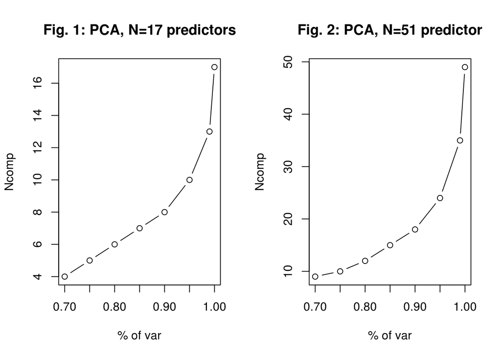

Application of PCA on the “max predictors” dataset (Fig.2) may help significantly: 95% of variability may be preserved with almost half size of dimensions. Thus, optimal threshold for PCA pre-processing may be kept default as in `trainControl` function help - it is 0.95.

### Step 3: model fit

Two alternative approaches evaluated:

- attempt “as is” on the small N predictors, large M cases;
- pre-preocessing on the large N predictors, small M cases.

Attempt on 17 predictors and 19622 cases “as is”. **NOTE: Since the model fit code takes too long to run it has been commented out.**

```r
# set.seed(13333)
# Perform model fit with methods: LDA, random forest, SVM and KNN
# # With default control method - bootstrap
# NCfitLDA <- train(xNC,yNC,method="lda",preProcess = c("center", "scale"))
# NCfitRF <- train(xNC,yNC,method="rf",preProcess = c("center", "scale"))
# NCfitSVM <- svm(xNC,yNC,kernel="radial")
# NCfitKNN <- train(xNC,yNC,method="knn",preProcess = c("center", "scale"))
# Make predictions
# NCpredLDA <- predict(object=NCfitLDA,newdata=xnewNC)
# NCpredRF <- predict(object=NCfitRF,newdata=xnewNC)
# NCpredSVM <- predict(object=NCfitSVM,newdata=xnewNC)
# Save result
# NCresult <- data.frame(LDA=NCpredLDA,RF=NCpredRF,SVM=NCpredSVM,KNN=NCpredKNN)
# write.csv(NCresult,file="~/NCresult.csv")
```

Perform the same task on the dataset with 51 predictor. Pre-processing with PCA is used to reduce number of predictors.

```r
# Perform model fit with methods: LDA, random forest, SVM and KNN
# NPfitLDA <- train(xNP,yNP,method="lda",preProcess = "pca")
# NPfitKNN <- train(xNP,yNP,method="knn",preProcess = "pca")
# NPfitRF <- train(xNP,yNP,method="rf",preProcess = "pca")
# NPfitSVM <- train(xNP,yNP,method="svmRadial",preProcess = "pca")
# Make predictions
# NPpredLDA <- predict(object=NPfitLDA,newdata=xnewNP)
# NPpredKNN <- predict(object=NPfitKNN,newdata=xnewNP)
# NPpredRF <- predict(object=NPfitRF,newdata=xnewNP)
# NPpredSVM <- predict(object=NPfitSVM,newdata=xnewNP)
# Save result
# NPresult <- data.frame(LDA=NPpredLDA,RF=NPpredRF,SVM=NPpredSVM,KNN=NPpredKNN)
# write.csv(NPresult,file="~/NPresult.csv")
```

### Step 4: collect the result

```
After all the models have been fitted and prediction made the final result is obtained by the major vote principle: take the answer according to the most frequent provided by various models. The following code illustrates that:
```

```r
# Load previously stored predctions
NCresult <- read.csv(file="~/MyGitHub/PML/NCresult.csv",row.names=1)
NPresult <- read.csv(file="~/MyGitHub/PML/NPresult.csv",row.names=1)
resfull <- data.frame(NCresult,NPresult)
names(resfull) <- c("NC_LDA","NC_RF","NC_SVM","NC_KNN","NP_LDA","NP_KNN")
finalvote <- rep ("A",20)
for (i in 1:20) {
  finalvote[i] <- names(which.max(table(t(resfull[i,]))))
}
print(t(resfull))
```

```
##        1   2   3   4   5   6   7   8   9   10  11  12  13  14  15  16  17
## NC_LDA "D" "A" "A" "C" "A" "C" "C" "D" "A" "A" "A" "A" "C" "A" "C" "E" "A"
## NC_RF  "B" "A" "B" "A" "A" "E" "D" "B" "A" "A" "B" "C" "B" "A" "E" "E" "A"
## NC_SVM "D" "A" "C" "C" "A" "E" "D" "D" "A" "A" "B" "C" "B" "A" "E" "E" "A"
## NC_KNN "B" "A" "B" "A" "A" "B" "D" "B" "A" "A" "B" "C" "B" "A" "E" "E" "A"
## NP_LDA "B" "A" "A" "A" "A" "C" "D" "D" "A" "C" "A" "A" "E" "A" "E" "B" "A"
## NP_KNN "B" "A" "B" "A" "A" "B" "D" "B" "A" "A" "B" "C" "B" "A" "E" "E" "A"
##        18  19  20
## NC_LDA "D" "D" "B"
## NC_RF  "B" "B" "B"
## NC_SVM "B" "D" "B"
## NC_KNN "B" "B" "B"
## NP_LDA "B" "A" "B"
## NP_KNN "B" "B" "B"
```

```r
print(finalvote)
```

```
##  [1] "B" "A" "B" "A" "A" "B" "D" "B" "A" "A" "B" "C" "B" "A" "E" "E" "A"
## [18] "B" "B" "B"
```

### Conclusion

[output not shown]